# Exponential Distribution is Normal?

Giulio Mario Martena

6/3/2020

## Overview

The purpose of this analysis is to verify the similarities between a normal an exponential distribution.

- *The exponential distribution is closely related to the Poisson distribution, and can be simulated in R with `rexp(n,λ)`, where λ is the rate parameter.*

The mean of the exponential distribution is `1/λ`, and the standard deviation is also `1/λ`.

In this study λ will be fixed to **0.2**.

*The distribution of averages across 40 exponential* will be investigated in this study, across 1000 simulations.

## Exponential distribution simulation

```r
λ <- 0.2
n <- 40 # Number of distributions
sims <- 1000 # Number of simulations per distribution

simulation <- replicate(sims, rexp(n,λ)) #replicate returns a matrix
meanExp <- apply(simulation,2,mean)
```

### Sample Mean versus Theoretical Mean

```r
meanSample <- mean(meanExp)
meanSample
```

```
## [1] 4.941153
```

```r
meanTheoretical <- 1 / λ
meanTheoretical
```

```
## [1] 5
```

The sample mean is 4.94, while the theoretical is 5. The difference between the two is 0.06, which is quite similar. The distribution is plotted in **plot 1**.

- Remark: the means are close to each other, and represent **the center of the distribution**.

The natural next step is to repeat the steps for the **variance**.

### Comparison of sample and theoretical variance of the distribution

```r
varianceSample <- var(meanExp)
varianceSample
```

```
## [1] 0.6323969
```

```r
varianceTheoretical <- (1 / λ * 1 / sqrt(n)) ^ 2
varianceTheoretical
```

```
## [1] 0.625
```

The sample standard deviation is 0.8, while the theoretical is 0.79. The difference between the two is 0.01.

### Check if distribution tends to a normal

*If theory checks out, the distribution should tend to a normal distribution with mean and standard deviation equal to the sample ones.*

```r
xfit <- seq(min(meanExp), max(meanExp), length = 2*n)
yfit <- dnorm(xfit, mean = meanSample, sd = sqrt(varianceSample))
```

The code above constructs a normal fit from the exponential means. **Plot 2** shows such similarity.

```r
mean(meanSample) + c(-1, 1) * qnorm(.975) * sqrt(varianceSample)/sqrt(n)
```

```
## [1] 4.694712 5.187594
```

The code above calculates the 95% C.I. for the sample mean.

- In terms of hypothesis this means that
  $$H_0: µ-µ_s = 0$$
  **cannot** be rejected.

Furthermore, the Q-Q plot in **plot 3** shows that normality is generally speaking a good approximation; this was expected from the CLT, of course, but how do we know we are not dealing with an actual normal distribution? Performing a normality check. In this case I will use [Kolmogorov-Smirnov test](https://en.wikipedia.org/wiki/Kolmogorov%E2%80%93Smirnov_test).

```r
ks.test(xfit, meanExp)
```

```
##
##  Two-sample Kolmogorov-Smirnov test
##
## data:  xfit and meanExp
## D = 0.202, p-value = 0.004739
## alternative hypothesis: two-sided
```

## Appendix

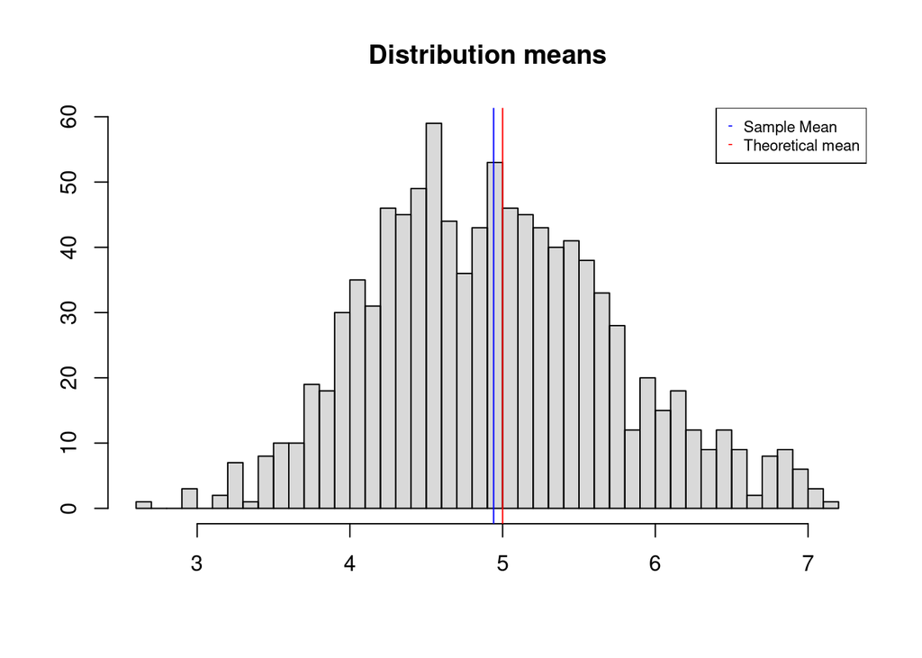

**Plot 1**: Histogram showing the sample (in blue) and theoretical (in red) mean of the distributions

```r
hist(meanExp, xlab="",ylab="", breaks = n, main="Distribution means", col = rgb(0,0,0,.15))
abline(v = meanSample, col='blue')
abline(v = meanTheoretical, col='red')
legend('topright', col=c('blue','red'), legend = c('Sample Mean','Theoretical mean'), pch='-', cex = .7)
```

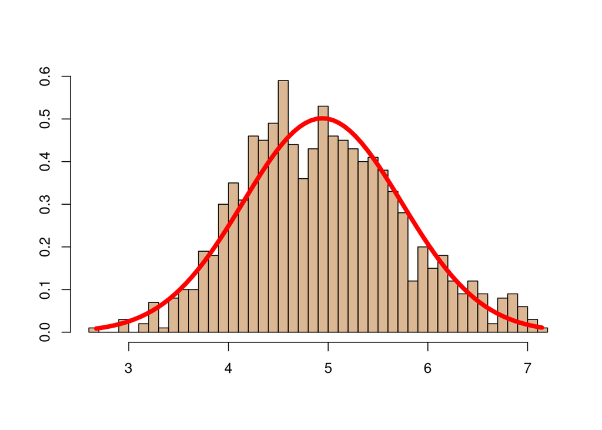

**Plot 2**: Exponential vs Normal Distribution

```r
hist(meanExp,breaks=n,prob=T,xlab = "",main="",ylab="",col=rgb(.8,.6,.4,.7))
lines(xfit, yfit, col='red', lwd=5)
```

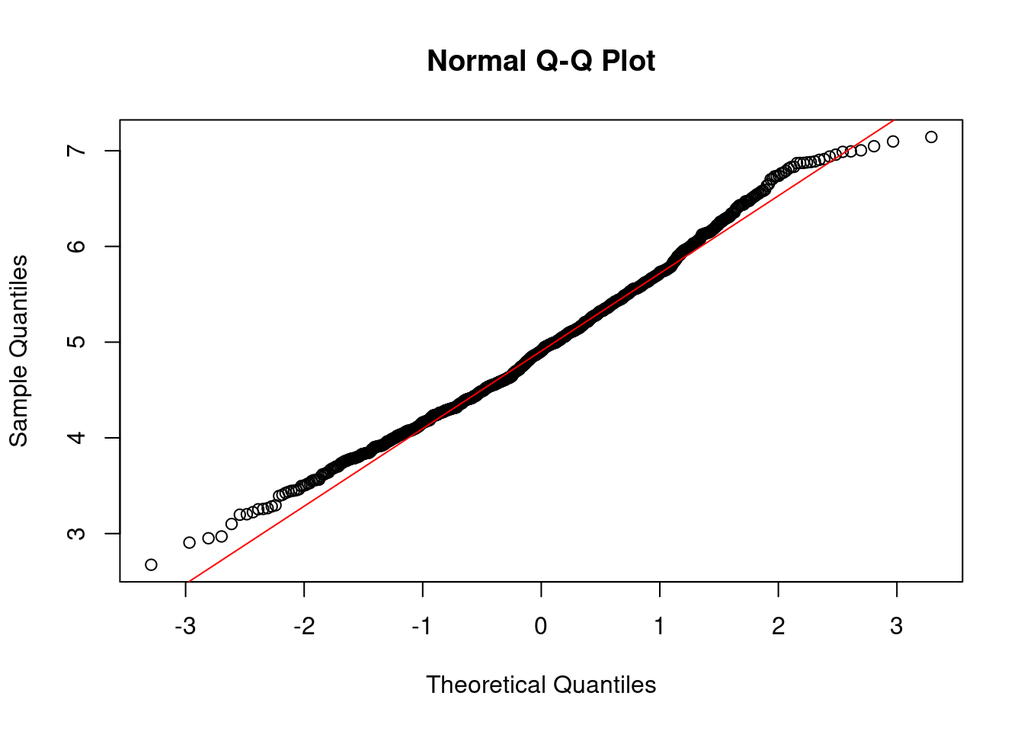

```r
qqnorm(meanExp);
qqline(meanExp, col = 'red')
```